# 11.5 案例分析（入门实战）

> 本章用两个小案例，贯通**数据准备 → 相关性 → 回归建模 → 预测与解读**的完整流程：
> - 案例一：学习时长与成绩
> - 案例二：城市居民生活满意度

## 学习目标

- 会将现实问题**转化为变量**并组织成 `DataFrame`。
- 用 `corr()` 计算相关矩阵，理解正/负相关与强弱。
- 用 `LinearRegression`（或 `numpy` 兜底）做线性回归并输出**斜率、截距、R²**。
- 能给出**自然语言解读**与**局限性**，避免“相关即因果”的误区。

## 语法要点（本章会用到）

- `pd.DataFrame({...})`：组装表格数据。
- `df.corr()`：皮尔逊相关（默认）。
- `groupby().agg(...)`：分组聚合（案例二使用）。
- 回归（优先）：

  ```
  from sklearn.linear_model import LinearRegression
  model = LinearRegression().fit(X, y)  # X 二维
  model.coef_, model.intercept_, model.score(X, y)  # 斜率/截距/R²
  ```

- 回归（兜底）：`numpy.linalg.lstsq` 最小二乘。
- 可视化：`matplotlib.pyplot` 中的 `scatter`/`plot`。

## 11.5.1 案例一：学习时长与成绩相关性分析

问题：**自习时间**是否与**考试成绩**相关？能否用来**预测**？

### （1）数据准备

```python
import pandas as pd
import numpy as np

data = {
    '姓名': ['学生A','学生B','学生C','学生D','学生E','学生F','学生G','学生H','学生I','学生J'],
    '每周自习时间': [5, 7, 4, 9, 6, 10, 8, 3, 7, 6],
    '考试成绩': [75, 82, 70, 90, 78, 92, 88, 68, 81, 79]
}
df = pd.DataFrame(data)
df
```

|  | 姓名 | 每周自习时间 | 考试成绩 |
| --- | --- | --- | --- |
| 0 | 学生A | 5 | 75 |
| 1 | 学生B | 7 | 82 |
| 2 | 学生C | 4 | 70 |
| 3 | 学生D | 9 | 90 |
| 4 | 学生E | 6 | 78 |
| 5 | 学生F | 10 | 92 |
| 6 | 学生G | 8 | 88 |
| 7 | 学生H | 3 | 68 |
| 8 | 学生I | 7 | 81 |
| 9 | 学生J | 6 | 79 |

### （2）相关性分析

```python
# 计算皮尔逊相关系数矩阵
corr_mat = df[['每周自习时间', '考试成绩']].corr()
corr_mat
```

|  | 每周自习时间 | 考试成绩 |
| --- | --- | --- |
| 每周自习时间 | 1.000000 | 0.991594 |
| 考试成绩 | 0.991594 | 1.000000 |

### （3）线性回归分析

```python
# 线性回归建模（优先 sklearn，若不可用则 numpy 兜底）
X = df[['每周自习时间']].to_numpy(dtype=float)
y = df['考试成绩'].to_numpy(dtype=float)

try:
    from sklearn.linear_model import LinearRegression
    model = LinearRegression().fit(X, y)
    slope = float(model.coef_[0])
    intercept = float(model.intercept_)
    r2 = float(model.score(X, y))
except Exception as e:
    Xd = np.column_stack([np.ones(len(X)), X.flatten()])  # [1, x]
    beta, *_ = np.linalg.lstsq(Xd, y, rcond=None)
    intercept = float(beta[0]); slope = float(beta[1])
    y_hat = Xd @ beta
    rss = float(((y - y_hat)**2).sum()); tss = float(((y - y.mean())**2).sum())
    r2 = 1 - rss/tss
    class _Model:
        def predict(self, Xnew):
            Xnew = np.asarray(Xnew, dtype=float).reshape(-1)
            return slope*Xnew + intercept
    model = _Model()

print("回归系数（斜率）：", round(slope, 2))
print("截距：", round(intercept, 2))
print("R²：", round(r2, 3))
```

```
回归系数（斜率）： 3.68
截距： 56.36
R²： 0.983
```

### （4）预测示例：小杨每周自习 12 小时

```python
# 预测成绩（学习时间 = 12）
predicted_score = model.predict([[12]]) if hasattr(model, 'predict') else (slope*12 + intercept)
pred = float(predicted_score[0]) if hasattr(predicted_score, '__len__') else float(predicted_score)
print("预测成绩:", round(pred, 2))
```

```
预测成绩: 100.55
```

### （5）可视化与结果解读

- 散点图 + 回归线，直观看到**正相关**。
- R² 显示模型能解释多少变异；但样本较小，仅做**入门示例**。

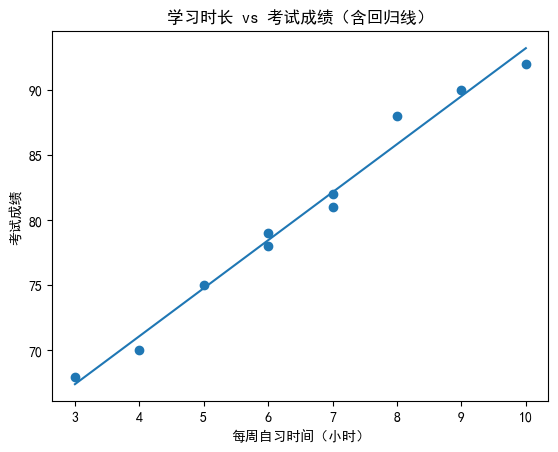

```python
import matplotlib.pyplot as plt
import numpy as np

# 设置支持中文的字体，例如黑体
plt.rcParams['font.sans-serif'] = ['SimHei']  # 或者 'Microsoft YaHei', 'FangSong', 'KaiTi' 等
plt.rcParams['axes.unicode_minus'] = False  # 解决负号显示问题

x = X.flatten()
plt.figure()
plt.scatter(x, y)  # 散点
x_line = np.linspace(x.min(), x.max(), 100)
y_line = slope * x_line + intercept
plt.plot(x_line, y_line)  # 回归线
plt.xlabel("每周自习时间（小时）")
plt.ylabel("考试成绩")
plt.title("学习时长 vs 考试成绩（含回归线）")
plt.show()
```

**一句话解读**：在该样本中，自习时间与成绩呈**显著正相关**，简单线性模型的预测在**样本内**表现良好。  
**注意**：相关不代表因果；还需控制基础能力、课程难度等潜在混杂因素。

## 11.5.2 案例二：城市居民生活满意度

问题：满意度与哪些因素相关？收入与教育是否有关联？

### （1）数据加载与初步探索

```python
# 模拟调查数据
df2 = pd.DataFrame({
    '年龄': [25, 32, 40, 29, 38, 45, 50, 28],
    '性别': ['女','男','女','女','男','男','男','女'],
    '教育水平': ['本科','硕士及以上','本科','高中及以下','本科','硕士及以上','硕士及以上','高中及以下'],
    '月收入': [6000, 18000, 8000, 3000, 7500, 20000, 15000, 4500],
    '满意度评分': [6, 9, 7, 4, 7, 10, 8, 5]
})

desc = df2.describe(include='all')
desc
```

|  | 年龄 | 性别 | 教育水平 | 月收入 | 满意度评分 |
| --- | --- | --- | --- | --- | --- |
| count | 8.000000 | 8 | 8 | 8.000000 | 8.00 |
| unique | NaN | 2 | 3 | NaN | NaN |
| top | NaN | 女 | 本科 | NaN | NaN |
| freq | NaN | 4 | 3 | NaN | NaN |
| mean | 35.875000 | NaN | NaN | 10250.000000 | 7.00 |
| std | 8.838835 | NaN | NaN | 6480.740698 | 2.00 |
| min | 25.000000 | NaN | NaN | 3000.000000 | 4.00 |
| 25% | 28.750000 | NaN | NaN | 5625.000000 | 5.75 |
| 50% | 35.000000 | NaN | NaN | 7750.000000 | 7.00 |
| 75% | 41.250000 | NaN | NaN | 15750.000000 | 8.25 |
| max | 50.000000 | NaN | NaN | 20000.000000 | 10.00 |

### （2）分组与聚合分析

```python
# 按教育水平分组，查看平均收入与平均满意度
grouped = df2.groupby('教育水平')[['月收入', '满意度评分']].mean().round(2)
grouped
```

| 教育水平 | 月收入 | 满意度评分 |
| --- | --- | --- |
| 本科 | 7166.67 | 6.67 |
| 硕士及以上 | 17666.67 | 9.00 |
| 高中及以下 | 3750.00 | 4.50 |

### （3）相关性分析

```python
# 收入与满意度的相关性（皮尔逊）
corr2 = df2[['月收入', '满意度评分']].corr()
corr2
```

|  | 月收入 | 满意度评分 |
| --- | --- | --- |
| 月收入 | 1.000000 | 0.958885 |
| 满意度评分 | 0.958885 | 1.000000 |

### （4）简单线性回归分析（收入 → 满意度）

```python
X2 = df2[['月收入']].to_numpy(dtype=float)
y2 = df2['满意度评分'].to_numpy(dtype=float)

try:
    from sklearn.linear_model import LinearRegression
    model2 = LinearRegression().fit(X2, y2)
    coef2 = float(model2.coef_[0])
    intercept2 = float(model2.intercept_)
    r2_2 = float(model2.score(X2, y2))
except Exception as e:
    Xd2 = np.column_stack([np.ones(len(X2)), X2.flatten()])
    beta2, *_ = np.linalg.lstsq(Xd2, y2, rcond=None)
    intercept2, coef2 = float(beta2[0]), float(beta2[1])
    yhat2 = Xd2 @ beta2
    rss2 = float(((y2 - yhat2)**2).sum()); tss2 = float(((y2 - y2.mean())**2).sum())
    r2_2 = 1 - rss2/tss2
    class _Model2:
        def predict(self, Xnew):
            Xnew = np.asarray(Xnew, dtype=float).reshape(-1)
            return coef2*Xnew + intercept2
    model2 = _Model2()

print("回归系数:", round(coef2, 4))
print("截距:", round(intercept2, 2))
print("R-squared:", round(r2_2, 2))
```

```
回归系数: 0.0003
截距: 3.97
R-squared: 0.92
```

### （5）可视化与启示

- 用散点 + 回归线直观查看**正向关系**。
- 局限：样本小、未控制其他变量（如住房、健康、婚姻等），**结论仅供参考**。

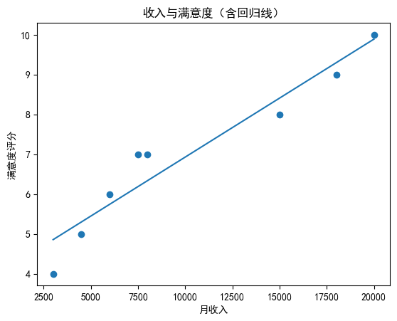

```python
import matplotlib.pyplot as plt

x2 = X2.flatten()
plt.figure()
plt.scatter(x2, y2)
x_line2 = np.linspace(x2.min(), x2.max(), 100)
y_line2 = coef2 * x_line2 + intercept2
plt.plot(x_line2, y_line2)
plt.xlabel("月收入")
plt.ylabel("满意度评分")
plt.title("收入与满意度（含回归线）")
plt.show()
```

## 注意事项（常见坑）

1. **相关不等于因果**：可能存在共同原因或反向因果。
2. **样本量与代表性**：小样本结论不稳健；调查需关注抽样方法与偏差。
3. **变量定义与测量**：满意度的量表区间、收入的单位与范围需明确。
4. **模型假设**：线性、独立、同方差与残差正态性只是理想化假设，实际研究要做**诊断**。

## 练习（建议先做再看答案）

**练习 1（案例一）**：  
在原数据中加入两名学生记录（自拟时间与成绩），重新计算**相关系数**与**回归参数**，并预测 `每周自习=11` 的成绩。

**练习 2（案例二）**：  
将“教育水平”重新编码为有序数值（如 高中及以下=1，本科=2，硕士及以上=3），与“满意度评分”一起计算**Spearman 等级相关**（若无 `scipy`，请用 `corr(method='spearman')`）。

**练习 3（可视化）**：  
分别为两个案例画**散点 + 回归线**，并用一句话解读图形特征（是否有离群点、线性趋势是否明显）。

```python
# === 在此动手做题（你可以多建几个单元格）===
import numpy as np
import pandas as pd
import matplotlib.pyplot as plt

# 练习 1：案例一扩展


# 练习 2：案例二 Spearman 等级相关


# 练习 3：两案例可视化 + 一句话解读
```

## 参考答案（对照自检）

> 说明：答案仅示例；请用自然语言把数值含义讲清楚。

```python
# 练习 1 参考答案
import numpy as np
import pandas as pd

df_ext = df.copy()
df_ext.loc[len(df_ext)] = ['学生K', 11, 89]
df_ext.loc[len(df_ext)] = ['学生L', 12, 94]

X_ext = df_ext[['每周自习时间']].to_numpy(dtype=float)
y_ext = df_ext['考试成绩'].to_numpy(dtype=float)

try:
    from sklearn.linear_model import LinearRegression
    m_ext = LinearRegression().fit(X_ext, y_ext)
    slope_e = float(m_ext.coef_[0]); inter_e = float(m_ext.intercept_)
    r2_e = float(m_ext.score(X_ext, y_ext))
    pred11 = float(m_ext.predict([[11]])[0])
except Exception:
    Xd = np.column_stack([np.ones(len(X_ext)), X_ext.flatten()])
    beta, *_ = np.linalg.lstsq(Xd, y_ext, rcond=None)
    inter_e, slope_e = float(beta[0]), float(beta[1])
    yhat = Xd @ beta
    rss = float(((y_ext - yhat)**2).sum()); tss = float(((y_ext - y_ext.mean())**2).sum())
    r2_e = 1 - rss/tss
    pred11 = slope_e*11 + inter_e

print("相关系数：\n", df_ext[['每周自习时间','考试成绩']].corr())
print("回归：斜率=", round(slope_e,2), "截距=", round(inter_e,2), "R²=", round(r2_e,3))
print("预测（每周自习=11）:", round(pred11,2))
```

```
相关系数：
           每周自习时间      考试成绩
每周自习时间  1.000000  0.964944
考试成绩    0.964944  1.000000
回归：斜率= 2.98 截距= 60.31 R²= 0.931
预测（每周自习=11）: 93.09
```

```python
# 练习 2 参考答案（Spearman）
df2_ = df2.copy()
edu_map = {'高中及以下':1, '本科':2, '硕士及以上':3}
df2_['教育编码'] = df2_['教育水平'].map(edu_map)

try:
    from scipy import stats
    rho, p = stats.spearmanr(df2_['教育编码'], df2_['满意度评分'])
    print("Spearman ρ:", round(float(rho),3), " p值:", round(float(p),4))
except Exception:
    print(df2_[['教育编码','满意度评分']].corr(method='spearman'))
```

```
Spearman ρ: 0.951  p值: 0.0003
```

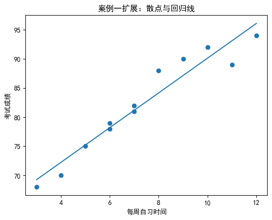

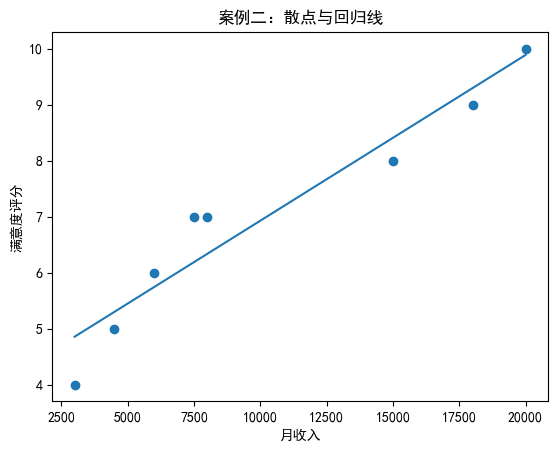

```
解读示例：两图均呈现正向线性趋势，案例二因样本少、点位分散，线性关系的不确定性更高。
```

```python
# 练习 3 参考答案（画图）
import matplotlib.pyplot as plt
import numpy as np

# 案例一
x1 = df_ext['每周自习时间'].to_numpy(dtype=float)
y1 = df_ext['考试成绩'].to_numpy(dtype=float)
Xd1 = np.column_stack([np.ones_like(x1), x1])
b1, *_ = np.linalg.lstsq(Xd1, y1, rcond=None)
b0_, b1_ = float(b1[0]), float(b1[1])

plt.figure()
plt.scatter(x1, y1)
xline = np.linspace(x1.min(), x1.max(), 100)
yline = b0_ + b1_*xline
plt.plot(xline, yline)
plt.xlabel("每周自习时间")
plt.ylabel("考试成绩")
plt.title("案例一扩展：散点与回归线")
plt.show()

# 案例二
x2 = df2['月收入'].to_numpy(dtype=float)
y2 = df2['满意度评分'].to_numpy(dtype=float)
Xd2 = np.column_stack([np.ones_like(x2), x2])
b2, *_ = np.linalg.lstsq(Xd2, y2, rcond=None)
c0_, c1_ = float(b2[0]), float(b2[1])

plt.figure()
plt.scatter(x2, y2)
xline2 = np.linspace(x2.min(), x2.max(), 100)
yline2 = c0_ + c1_*xline2
plt.plot(xline2, yline2)
plt.xlabel("月收入")
plt.ylabel("满意度评分")
plt.title("案例二：散点与回归线")
plt.show()

print("解读示例：两图均呈现正向线性趋势，案例二因样本少、点位分散，线性关系的不确定性更高。")
```

## 小结

- 将研究问题转为**变量与表格**是第一步。
- **相关性**用于先验探索，**回归**用于定量关系与预测。
- 报告时需说明：样本量、统计方法、估计值与不确定性、局限与假设。

> 下一步：在案例中加入**残差诊断/QQ 图**与**多元回归**，并尝试使用交叉验证评估泛化能力（进阶）。